# Project: Investigate TMDb movie data set

- Introduction
- Data Wrangling
- Exploratory Data Analysis
- Conclusions

## Introduction

```python
# Use this cell to set up import statements for all of the packages that you
#   plan to use.
import pandas as pd
import numpy as np
import matplotlib.pyplot as plt
%matplotlib inline

# changing revenue and budget columns format from exponential to scientific
# Reference: https://stackoverflow.com/questions/38689125/how-to-get-rid-of-pandas-converting-large-numbers-in-excel-sheet-to-exponential
pd.set_option('display.float_format', '{:.2f}'.format)
```

## Data Wrangling

### General Properties

```python
# Load your data and print out a few lines. Perform operations to inspect data
#   types and look for instances of missing or possibly errant data.
df = pd.read_csv('tmdb-movies.csv')
df.head()
```

|  | id | imdb_id | popularity | budget | revenue | original_title | cast | homepage | director | tagline | ... | overview | runtime | genres | production_companies | release_date | vote_count | vote_average | release_year | budget_adj | revenue_adj |
| --- | --- | --- | --- | --- | --- | --- | --- | --- | --- | --- | --- | --- | --- | --- | --- | --- | --- | --- | --- | --- | --- |
| 0 | 135397 | tt0369610 | 32.99 | 150000000 | 1513528810 | Jurassic World | Chris Pratt\|Bryce Dallas Howard\|Irrfan Khan\|Vi... | http://www.jurassicworld.com/ | Colin Trevorrow | The park is open. | ... | Twenty-two years after the events of Jurassic ... | 124 | Action\|Adventure\|Science Fiction\|Thriller | Universal Studios\|Amblin Entertainment\|Legenda... | 6/9/15 | 5562 | 6.50 | 2015 | 137999939.28 | 1392445892.52 |
| 1 | 76341 | tt1392190 | 28.42 | 150000000 | 378436354 | Mad Max: Fury Road | Tom Hardy\|Charlize Theron\|Hugh Keays-Byrne\|Nic... | http://www.madmaxmovie.com/ | George Miller | What a Lovely Day. | ... | An apocalyptic story set in the furthest reach... | 120 | Action\|Adventure\|Science Fiction\|Thriller | Village Roadshow Pictures\|Kennedy Miller Produ... | 5/13/15 | 6185 | 7.10 | 2015 | 137999939.28 | 348161292.49 |
| 2 | 262500 | tt2908446 | 13.11 | 110000000 | 295238201 | Insurgent | Shailene Woodley\|Theo James\|Kate Winslet\|Ansel... | http://www.thedivergentseries.movie/#insurgent | Robert Schwentke | One Choice Can Destroy You | ... | Beatrice Prior must confront her inner demons ... | 119 | Adventure\|Science Fiction\|Thriller | Summit Entertainment\|Mandeville Films\|Red Wago... | 3/18/15 | 2480 | 6.30 | 2015 | 101199955.47 | 271619025.41 |
| 3 | 140607 | tt2488496 | 11.17 | 200000000 | 2068178225 | Star Wars: The Force Awakens | Harrison Ford\|Mark Hamill\|Carrie Fisher\|Adam D... | http://www.starwars.com/films/star-wars-episod... | J.J. Abrams | Every generation has a story. | ... | Thirty years after defeating the Galactic Empi... | 136 | Action\|Adventure\|Science Fiction\|Fantasy | Lucasfilm\|Truenorth Productions\|Bad Robot | 12/15/15 | 5292 | 7.50 | 2015 | 183999919.04 | 1902723129.80 |
| 4 | 168259 | tt2820852 | 9.34 | 190000000 | 1506249360 | Furious 7 | Vin Diesel\|Paul Walker\|Jason Statham\|Michelle ... | http://www.furious7.com/ | James Wan | Vengeance Hits Home | ... | Deckard Shaw seeks revenge against Dominic Tor... | 137 | Action\|Crime\|Thriller | Universal Pictures\|Original Film\|Media Rights ... | 4/1/15 | 2947 | 7.30 | 2015 | 174799923.09 | 1385748801.47 |

5 rows × 21 columns

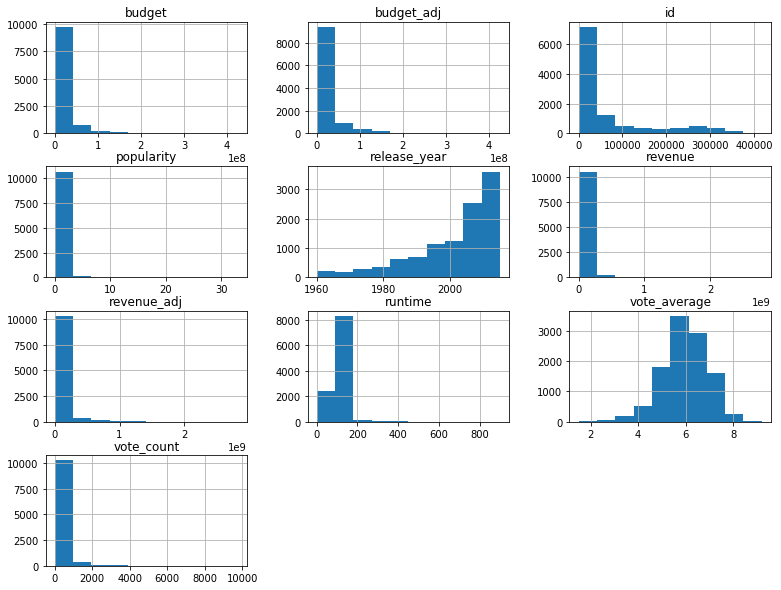

```python
df.hist(figsize = (13,10));
```

```python
df.describe()
```

|  | id | popularity | budget | revenue | runtime | vote_count | vote_average | release_year | budget_adj | revenue_adj |
| --- | --- | --- | --- | --- | --- | --- | --- | --- | --- | --- |
| count | 10866.00 | 10866.00 | 10866.00 | 10866.00 | 10866.00 | 10866.00 | 10866.00 | 10866.00 | 10866.00 | 10866.00 |
| mean | 66064.18 | 0.65 | 14625701.09 | 39823319.79 | 102.07 | 217.39 | 5.97 | 2001.32 | 17551039.82 | 51364363.25 |
| std | 92130.14 | 1.00 | 30913213.83 | 117003486.58 | 31.38 | 575.62 | 0.94 | 12.81 | 34306155.72 | 144632485.04 |
| min | 5.00 | 0.00 | 0.00 | 0.00 | 0.00 | 10.00 | 1.50 | 1960.00 | 0.00 | 0.00 |
| 25% | 10596.25 | 0.21 | 0.00 | 0.00 | 90.00 | 17.00 | 5.40 | 1995.00 | 0.00 | 0.00 |
| 50% | 20669.00 | 0.38 | 0.00 | 0.00 | 99.00 | 38.00 | 6.00 | 2006.00 | 0.00 | 0.00 |
| 75% | 75610.00 | 0.71 | 15000000.00 | 24000000.00 | 111.00 | 145.75 | 6.60 | 2011.00 | 20853251.08 | 33697095.72 |
| max | 417859.00 | 32.99 | 425000000.00 | 2781505847.00 | 900.00 | 9767.00 | 9.20 | 2015.00 | 425000000.00 | 2827123750.41 |

```python
#checking NaN and zero values
df.isnull().sum()
```

```
id                         0
imdb_id                   10
popularity                 0
budget                     0
revenue                    0
original_title             0
cast                      76
homepage                7930
director                  44
tagline                 2824
keywords                1493
overview                   4
runtime                    0
genres                    23
production_companies    1030
release_date               0
vote_count                 0
vote_average               0
release_year               0
budget_adj                 0
revenue_adj                0
dtype: int64
```

```python
#checking the effect of replacing zero values with NaN
df.replace(0, np.nan).isna().sum()
```

```
id                         0
imdb_id                   10
popularity                 0
budget                  5696
revenue                 6016
original_title             0
cast                      76
homepage                7930
director                  44
tagline                 2824
keywords                1493
overview                   4
runtime                   31
genres                    23
production_companies    1030
release_date               0
vote_count                 0
vote_average               0
release_year               0
budget_adj              5696
revenue_adj             6016
dtype: int64
```

```python
#checking duplicated rows
df.duplicated().sum()
```

```
1
```

### Data overview

The following columns will be dropped as they will non be used in the analysis:

- production_companies
- release_date
- keywords
- tagline
- homepage
- imdb_id
- director

There are many columns with more than one entry separated by "|" delimiter, also duplicated row to be removed and zero values to be replaced with "nan"

Many movies have missing vlaues in genres and cast so it would be better to exclude these movies from the analysis

### Data Cleaning

```python
#replacing zero values wirh nan
df.replace(0, np.nan, inplace = True)
df.isna().sum()
```

```
id                         0
imdb_id                   10
popularity                 0
budget                  5696
revenue                 6016
original_title             0
cast                      76
homepage                7930
director                  44
tagline                 2824
keywords                1493
overview                   4
runtime                   31
genres                    23
production_companies    1030
release_date               0
vote_count                 0
vote_average               0
release_year               0
budget_adj              5696
revenue_adj             6016
dtype: int64
```

```python
#dropping duplicate row
df.drop_duplicates(inplace = True)
df.shape
```

```
(10865, 21)
```

```python
df.drop(['production_companies', 'release_date', 'keywords', 'tagline', 'homepage', 'imdb_id', 'director'], axis = 1, inplace = True)
df.shape
```

```
(10865, 14)
```

```python
# Removing rows with nan values in genres and cast columns
df_genres_clean = df.dropna(subset =['genres', 'cast'])

df_genres_clean.isna().sum()
```

```
id                   0
popularity           0
budget            5610
revenue           5923
original_title       0
cast                 0
overview             3
runtime             30
genres               0
vote_count           0
vote_average         0
release_year         0
budget_adj        5610
revenue_adj       5923
dtype: int64
```

```python
# Create new Data frame with null values in revenue and budget removed
df_revenue_clean = df.dropna(subset =['budget_adj', 'revenue_adj'])

df_revenue_clean.isna().sum()
```

```
id                0
popularity        0
budget            0
revenue           0
original_title    0
cast              4
overview          0
runtime           0
genres            0
vote_count        0
vote_average      0
release_year      0
budget_adj        0
revenue_adj       0
dtype: int64
```

## Exploratory Data Analysis

Which genres are most popular from year to year?

### Question 1 - Which genres are most popular from year to year?

```python
# Create a data frame with genre count for each year
year_list= sorted(df_genres_clean['release_year'].drop_duplicates().tolist())
genrs_year_df = pd.DataFrame()
for year in year_list:
    genre_dict = {}
    genres_in_year = df_genres_clean[df_genres_clean.release_year == year]
    genres_in_year = genres_in_year["genres"].values
    for cell in genres_in_year:
        genres_row = cell.split("|")
        for genre in genres_row:
            if genre not in genre_dict:
                genre_dict[genre] = 1
            else:
                genre_dict[genre] = genre_dict[genre] + 1

    df_row = pd.DataFrame(genre_dict, index = [year])
    genrs_year_df = genrs_year_df.append(df_row, ignore_index = False, sort = True)
#replacing nan values with zero and
genrs_year_df.fillna(0, inplace = True)
#Change type of all values to integers
genrs_year_df.astype(int)
```

|  | Action | Adventure | Animation | Comedy | Crime | Documentary | Drama | Family | Fantasy | Foreign | History | Horror | Music | Mystery | Romance | Science Fiction | TV Movie | Thriller | War | Western |
| --- | --- | --- | --- | --- | --- | --- | --- | --- | --- | --- | --- | --- | --- | --- | --- | --- | --- | --- | --- | --- |
| 1960 | 8 | 5 | 0 | 8 | 2 | 0 | 13 | 3 | 2 | 1 | 5 | 7 | 1 | 0 | 6 | 3 | 0 | 6 | 2 | 6 |
| 1961 | 7 | 6 | 1 | 10 | 2 | 0 | 16 | 5 | 2 | 1 | 3 | 3 | 2 | 1 | 7 | 4 | 0 | 0 | 2 | 3 |
| 1962 | 8 | 7 | 0 | 5 | 3 | 0 | 21 | 2 | 1 | 1 | 4 | 5 | 1 | 4 | 5 | 2 | 0 | 7 | 3 | 3 |
| 1963 | 4 | 7 | 1 | 13 | 4 | 0 | 13 | 3 | 2 | 2 | 4 | 9 | 0 | 6 | 8 | 2 | 0 | 10 | 1 | 2 |
| 1964 | 5 | 5 | 2 | 16 | 10 | 0 | 20 | 4 | 4 | 1 | 3 | 6 | 5 | 4 | 9 | 4 | 0 | 9 | 3 | 1 |
| 1965 | 9 | 6 | 1 | 7 | 2 | 0 | 20 | 3 | 0 | 1 | 4 | 5 | 2 | 3 | 5 | 2 | 1 | 11 | 8 | 4 |
| 1966 | 14 | 11 | 3 | 16 | 5 | 1 | 16 | 7 | 2 | 2 | 2 | 3 | 0 | 6 | 6 | 6 | 0 | 8 | 4 | 7 |
| 1967 | 7 | 7 | 1 | 17 | 7 | 1 | 16 | 3 | 3 | 0 | 0 | 4 | 5 | 3 | 11 | 4 | 0 | 5 | 1 | 2 |
| 1968 | 6 | 5 | 3 | 9 | 5 | 0 | 19 | 5 | 5 | 0 | 3 | 4 | 3 | 4 | 6 | 4 | 0 | 5 | 4 | 1 |
| 1969 | 10 | 5 | 2 | 11 | 3 | 0 | 13 | 4 | 2 | 0 | 3 | 1 | 2 | 1 | 4 | 3 | 1 | 3 | 3 | 7 |
| 1970 | 11 | 6 | 2 | 12 | 4 | 3 | 19 | 3 | 3 | 1 | 3 | 5 | 4 | 3 | 6 | 3 | 1 | 5 | 5 | 8 |
| 1971 | 11 | 5 | 1 | 9 | 10 | 0 | 30 | 2 | 2 | 0 | 3 | 7 | 1 | 6 | 9 | 6 | 1 | 17 | 4 | 5 |
| 1972 | 10 | 5 | 1 | 13 | 7 | 1 | 16 | 2 | 1 | 0 | 0 | 8 | 2 | 4 | 5 | 4 | 0 | 10 | 0 | 5 |
| 1973 | 15 | 5 | 3 | 8 | 17 | 1 | 31 | 4 | 1 | 0 | 2 | 15 | 1 | 7 | 3 | 6 | 1 | 16 | 0 | 4 |
| 1974 | 14 | 8 | 1 | 12 | 15 | 2 | 21 | 4 | 3 | 0 | 1 | 8 | 1 | 5 | 4 | 5 | 1 | 20 | 1 | 2 |
| 1975 | 10 | 8 | 1 | 12 | 6 | 1 | 17 | 2 | 4 | 0 | 3 | 8 | 3 | 8 | 2 | 11 | 0 | 13 | 2 | 3 |
| 1976 | 13 | 6 | 0 | 12 | 8 | 1 | 22 | 3 | 2 | 1 | 2 | 9 | 3 | 7 | 5 | 5 | 1 | 17 | 2 | 3 |
| 1977 | 14 | 15 | 5 | 10 | 2 | 1 | 23 | 7 | 9 | 0 | 4 | 14 | 3 | 5 | 4 | 11 | 0 | 12 | 4 | 1 |
| 1978 | 15 | 11 | 2 | 14 | 6 | 3 | 29 | 6 | 5 | 1 | 2 | 19 | 3 | 7 | 5 | 16 | 3 | 22 | 4 | 1 |
| 1979 | 8 | 8 | 1 | 19 | 8 | 0 | 30 | 5 | 0 | 0 | 3 | 11 | 4 | 4 | 8 | 10 | 0 | 16 | 3 | 4 |
| 1980 | 27 | 14 | 0 | 25 | 9 | 0 | 32 | 4 | 7 | 2 | 5 | 16 | 4 | 9 | 9 | 11 | 1 | 25 | 2 | 5 |
| 1981 | 17 | 14 | 3 | 20 | 10 | 2 | 32 | 5 | 3 | 0 | 5 | 24 | 3 | 10 | 10 | 10 | 1 | 27 | 2 | 0 |
| 1982 | 17 | 10 | 6 | 28 | 9 | 1 | 33 | 8 | 13 | 2 | 2 | 20 | 6 | 10 | 12 | 13 | 1 | 17 | 2 | 2 |
| 1983 | 21 | 14 | 3 | 28 | 11 | 0 | 35 | 4 | 10 | 1 | 1 | 13 | 5 | 5 | 14 | 16 | 1 | 24 | 1 | 1 |
| 1984 | 33 | 22 | 0 | 38 | 15 | 2 | 40 | 9 | 15 | 0 | 5 | 18 | 11 | 4 | 19 | 27 | 1 | 24 | 3 | 0 |
| 1985 | 28 | 28 | 2 | 51 | 14 | 1 | 40 | 12 | 14 | 0 | 1 | 14 | 2 | 3 | 21 | 17 | 0 | 24 | 2 | 3 |
| 1986 | 30 | 17 | 6 | 49 | 18 | 0 | 51 | 12 | 11 | 0 | 3 | 30 | 6 | 7 | 25 | 21 | 0 | 23 | 4 | 1 |
| 1987 | 29 | 17 | 3 | 57 | 21 | 0 | 52 | 16 | 18 | 0 | 3 | 25 | 4 | 7 | 24 | 18 | 2 | 28 | 6 | 1 |
| 1988 | 31 | 14 | 5 | 69 | 21 | 4 | 53 | 15 | 15 | 1 | 4 | 36 | 7 | 9 | 19 | 18 | 2 | 33 | 6 | 0 |
| 1989 | 38 | 24 | 4 | 63 | 25 | 2 | 54 | 16 | 16 | 2 | 4 | 25 | 3 | 8 | 22 | 21 | 0 | 35 | 4 | 1 |
| 1990 | 39 | 23 | 4 | 48 | 30 | 1 | 60 | 12 | 13 | 1 | 4 | 26 | 2 | 14 | 19 | 18 | 1 | 46 | 2 | 3 |
| 1991 | 39 | 21 | 3 | 60 | 20 | 3 | 63 | 21 | 19 | 3 | 1 | 13 | 7 | 9 | 26 | 13 | 0 | 37 | 2 | 2 |
| 1992 | 34 | 17 | 4 | 54 | 25 | 0 | 65 | 16 | 14 | 3 | 4 | 16 | 6 | 10 | 31 | 16 | 0 | 45 | 1 | 2 |
| 1993 | 53 | 26 | 6 | 72 | 28 | 1 | 90 | 29 | 13 | 5 | 8 | 18 | 6 | 15 | 34 | 18 | 0 | 45 | 6 | 3 |
| 1994 | 61 | 33 | 8 | 88 | 26 | 2 | 83 | 35 | 24 | 3 | 3 | 13 | 3 | 10 | 35 | 20 | 5 | 45 | 3 | 8 |
| 1995 | 47 | 32 | 7 | 63 | 31 | 2 | 93 | 33 | 17 | 2 | 7 | 19 | 0 | 14 | 37 | 18 | 1 | 49 | 5 | 3 |
| 1996 | 42 | 30 | 8 | 91 | 19 | 3 | 104 | 31 | 22 | 2 | 5 | 17 | 4 | 13 | 44 | 24 | 2 | 61 | 3 | 0 |
| 1997 | 59 | 35 | 9 | 76 | 28 | 2 | 83 | 32 | 21 | 3 | 7 | 18 | 4 | 21 | 32 | 29 | 1 | 61 | 1 | 0 |
| 1998 | 43 | 38 | 16 | 84 | 34 | 3 | 108 | 34 | 22 | 4 | 7 | 23 | 12 | 18 | 41 | 26 | 3 | 53 | 3 | 1 |
| 1999 | 38 | 20 | 13 | 100 | 29 | 5 | 113 | 29 | 23 | 6 | 7 | 26 | 5 | 24 | 42 | 29 | 6 | 53 | 3 | 3 |
| 2000 | 47 | 28 | 25 | 97 | 31 | 3 | 100 | 34 | 21 | 4 | 4 | 21 | 10 | 14 | 47 | 24 | 1 | 63 | 5 | 2 |
| 2001 | 61 | 40 | 18 | 101 | 39 | 5 | 100 | 31 | 25 | 4 | 12 | 23 | 6 | 22 | 53 | 25 | 10 | 66 | 12 | 2 |
| 2002 | 72 | 45 | 21 | 104 | 41 | 8 | 129 | 39 | 20 | 11 | 8 | 30 | 3 | 28 | 48 | 28 | 3 | 83 | 7 | 1 |
| 2003 | 73 | 41 | 29 | 111 | 46 | 11 | 110 | 44 | 27 | 5 | 9 | 24 | 11 | 19 | 49 | 41 | 3 | 73 | 8 | 4 |
| 2004 | 75 | 49 | 23 | 125 | 32 | 12 | 141 | 40 | 19 | 7 | 7 | 29 | 13 | 27 | 63 | 34 | 6 | 74 | 8 | 7 |
| 2005 | 70 | 53 | 24 | 143 | 45 | 17 | 182 | 56 | 34 | 10 | 10 | 56 | 13 | 29 | 62 | 25 | 3 | 92 | 5 | 2 |
| 2006 | 79 | 55 | 35 | 155 | 53 | 16 | 196 | 63 | 34 | 10 | 12 | 56 | 11 | 30 | 70 | 30 | 8 | 114 | 7 | 1 |
| 2007 | 95 | 60 | 32 | 151 | 65 | 16 | 197 | 45 | 47 | 17 | 12 | 79 | 15 | 34 | 74 | 41 | 6 | 125 | 6 | 5 |
| 2008 | 99 | 63 | 32 | 168 | 62 | 25 | 233 | 55 | 43 | 18 | 23 | 76 | 20 | 29 | 84 | 52 | 5 | 127 | 17 | 2 |
| 2009 | 108 | 72 | 47 | 198 | 52 | 23 | 224 | 60 | 48 | 17 | 16 | 90 | 17 | 50 | 83 | 71 | 8 | 157 | 12 | 0 |
| 2010 | 107 | 59 | 50 | 169 | 50 | 30 | 210 | 55 | 44 | 13 | 14 | 78 | 10 | 32 | 85 | 45 | 8 | 134 | 7 | 6 |
| 2011 | 115 | 61 | 42 | 171 | 48 | 45 | 213 | 70 | 45 | 13 | 8 | 78 | 17 | 38 | 75 | 56 | 10 | 146 | 9 | 3 |
| 2012 | 99 | 50 | 36 | 174 | 54 | 45 | 231 | 42 | 33 | 6 | 12 | 104 | 22 | 33 | 79 | 54 | 14 | 160 | 10 | 4 |
| 2013 | 121 | 67 | 42 | 175 | 71 | 59 | 253 | 48 | 39 | 0 | 14 | 102 | 30 | 38 | 65 | 61 | 10 | 175 | 7 | 3 |
| 2014 | 129 | 67 | 35 | 184 | 65 | 62 | 284 | 43 | 36 | 0 | 15 | 105 | 28 | 36 | 84 | 61 | 14 | 178 | 22 | 6 |
| 2015 | 106 | 69 | 37 | 162 | 51 | 52 | 260 | 44 | 33 | 0 | 15 | 125 | 33 | 42 | 57 | 85 | 20 | 171 | 9 | 6 |

```python
# most popular genre in each year
pop_gen_year = genrs_year_df.idxmax(axis=1)
#print(pop_gen_year.values)
gen_count = genrs_year_df.max(axis=1)
#print(gen_count.values)
pop_gen_df = pd.DataFrame([pop_gen_year.values, gen_count.values] , columns = pop_gen_year.index , index = ['genre', 'count'])
#most popular genre by year data frame
pop_gen_df
```

|  | 1960 | 1961 | 1962 | 1963 | 1964 | 1965 | 1966 | 1967 | 1968 | 1969 | ... | 2006 | 2007 | 2008 | 2009 | 2010 | 2011 | 2012 | 2013 | 2014 | 2015 |
| --- | --- | --- | --- | --- | --- | --- | --- | --- | --- | --- | --- | --- | --- | --- | --- | --- | --- | --- | --- | --- | --- |
| genre | Drama | Drama | Drama | Comedy | Drama | Drama | Comedy | Comedy | Drama | Drama | ... | Drama | Drama | Drama | Drama | Drama | Drama | Drama | Drama | Drama | Drama |
| count | 13.00 | 16.00 | 21.00 | 13.00 | 20.00 | 20.00 | 16.00 | 17.00 | 19.00 | 13.00 | ... | 196.00 | 197.00 | 233.00 | 224.00 | 210.00 | 213.00 | 231.00 | 253.00 | 284.00 | 260.00 |

2 rows × 56 columns

#### Note:

with the data frame above we can get the most genre produced in each year.

A stacked bar plot will be a good way to see an overview of genres change from year to year.

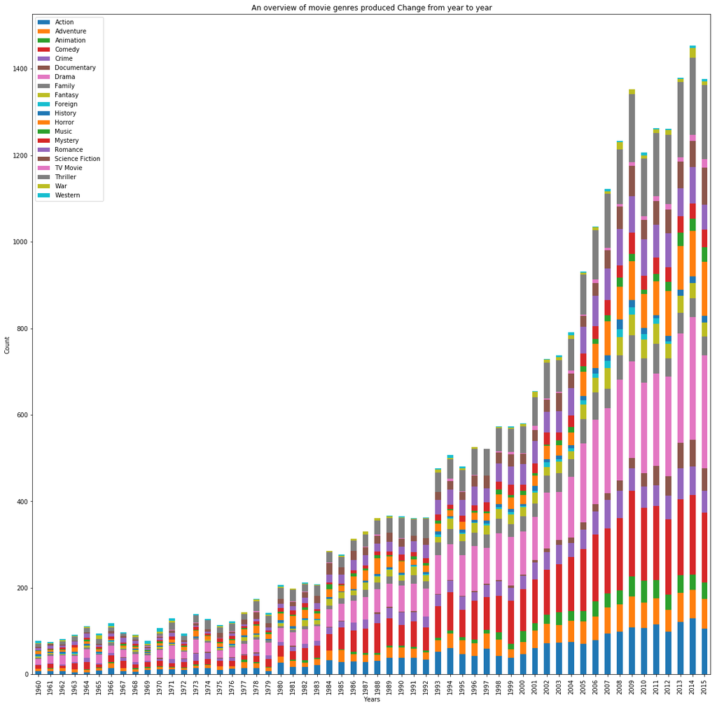

```python
genrs_year_df.plot(kind= 'bar', stacked= True,figsize = (20,20));
plt.xlabel('Years');
plt.ylabel('Count');
plt.title('An overview of movie genres produced Change from year to year');
```

#### Note:

the above stacked bar chart shows the genre chage from year to year. This shows that generally movies produced increase from year to year; however, the amount produced for each genre may increase or decrease each year

we can also see which genre is produced throughout the years

```python
# most common genre throgh all the years
pop_gen_df.transpose(copy=True)['genre'].mode()[0]
```

```
'Drama'
```

### Question 2 - Who are the actors with most appearences through these years?

```python
actor_dict = {}

actors = df_genres_clean["cast"]
#print(actors)
actors = actors.str.split("|")
#print(actors)
actors = np.array(actors)
#print(actors)
for actor_list in actors:
    for actor in actor_list:
        actor = actor.strip()
        if actor not in actor_dict:
            actor_dict[actor] = 1
        else:
            actor_dict[actor] += 1

#print(actor_dict)
#getting top 15 actors in the actor dictionary
## sorting dictionary
### References: https://stackoverflow.com/questions/613183/how-do-i-sort-a-dictionary-by-value
#               https://careerkarma.com/blog/python-sort-a-dictionary-by-value/
sorted_actors = sorted(actor_dict.items(), key=lambda item: item[1], reverse = True)
dict(sorted_actors[:15])
```

```
{'Robert De Niro': 72,
 'Samuel L. Jackson': 71,
 'Bruce Willis': 62,
 'Nicolas Cage': 61,
 'Michael Caine': 53,
 'Robin Williams': 51,
 'John Cusack': 50,
 'John Goodman': 49,
 'Morgan Freeman': 49,
 'Liam Neeson': 48,
 'Susan Sarandon': 48,
 'Alec Baldwin': 47,
 'Julianne Moore': 47,
 'Tom Hanks': 46,
 'Johnny Depp': 46}
```

#### Note:

A bar plot is a good way to visualize the top 15 actors throughout the years.

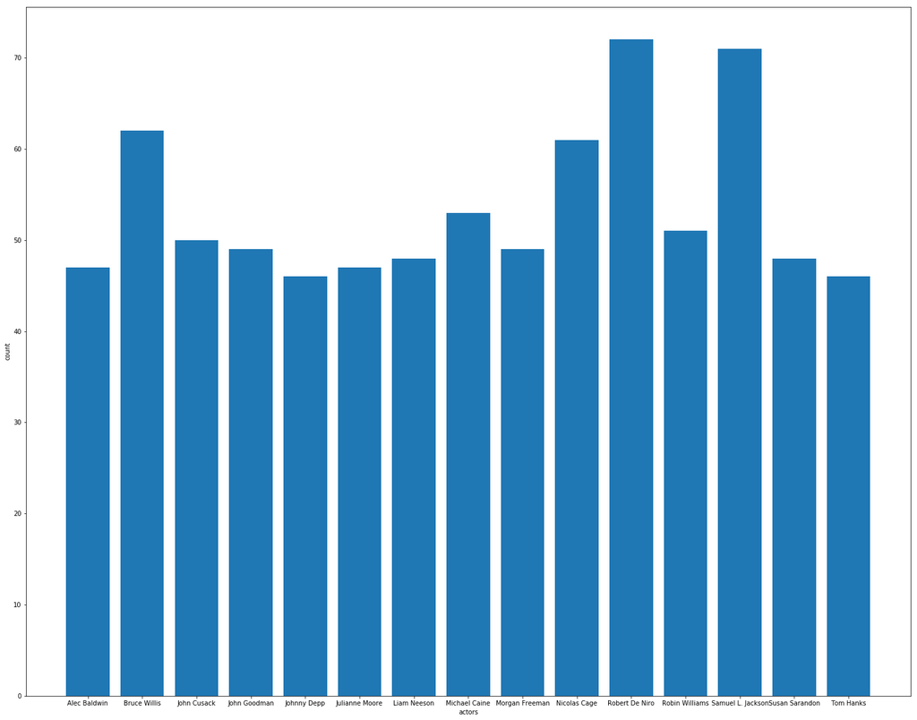

```python
plt.figure(figsize=(25,20));
plt.bar(dict(sorted_actors[:15]).keys(), dict(sorted_actors[:15]).values(), align='center');
plt.xlabel('actors');
plt.ylabel('count');
```

#### Note:

The above diagram shows that the most active actor throughout the years is Robert De Niro

### Question 3 - What kinds of properties are associated with movies that have high revenues?

```python
#drop unused columns
print(df_revenue_clean.shape)
df_revenue_clean = df_revenue_clean.drop(['id', 'budget', 'revenue', 'vote_count'], axis = 1)
```

```
(3854, 14)
```

```python
df_revenue_clean.shape
```

```
(3854, 10)
```

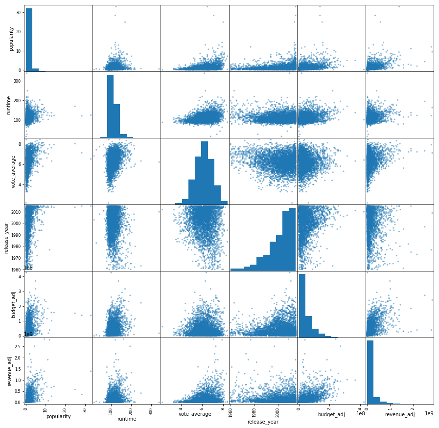

```python
# Exploring correlations
pd.plotting.scatter_matrix(df_revenue_clean, figsize=(15,15));
```

Reference used for plotting trendline: https://www.tutorialspoint.com/how-can-i-draw-a-scatter-trend-line-using-matplotlib

The above diagram shows different correlations between the data frame columns which gives an overview to the relation between differnt columns of the data frame. Next we can take a closr look for the correlations between **revenue** and other features

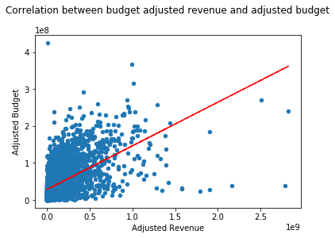

```python
# Correlation between revenue and budget
x=df_revenue_clean.revenue_adj
y=df_revenue_clean.budget_adj
df_revenue_clean.plot(x='revenue_adj', y='budget_adj', kind='scatter');
z = np.polyfit(x, y, 1);
p = np.poly1d(z);
plt.plot(x,p(x),"r--");
plt.title('Correlation between budget adjusted revenue and adjusted budget', y=1.1);
plt.xlabel('Adjusted Revenue');
plt.ylabel('Adjusted Budget');
```

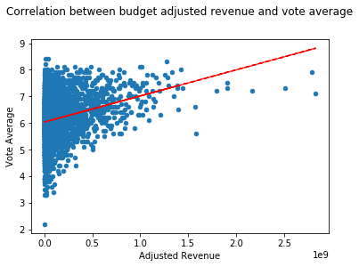

```python
# Correlation between revenue and vote average
x=df_revenue_clean.revenue_adj
y=df_revenue_clean.vote_average
df_revenue_clean.plot(x='revenue_adj', y='vote_average', kind='scatter');
z = np.polyfit(x, y, 1);
p = np.poly1d(z);
plt.plot(x,p(x),"r--");
plt.title('Correlation between budget adjusted revenue and vote average', y=1.1);
plt.xlabel('Adjusted Revenue');
plt.ylabel('Vote Average');
```

Tha above diagrams shows positive Correlations between **revenue** and both **budget** and **vote average**

## Conclusions

### Question 1 - Which genres are most popular from year to year?

the most produced genre through the years was "Drama" there is an increase of number of movies produced each year

### Question 2 - Who are the actors with most appearences through these years?

the top five actors were

1. Robert De Niro : 72 appearences
2. Samuel L. Jackson: 71 appearences
3. Bruce Willis: 62 appearences
4. Nicolas Cage: 61 appearences
5. Michael Caine: 53 appearences

### Question 3 - What kinds of properties are associated with movies that have high revenues?

there is a positive corelation between revenue and both budget and vote average

## Limitations

the Data is so vast and there is a lot of more information that can be extracted from it such as:

- most active directors
- how many times did an actor appear in movies each year
- more correlation between revenue and other features
- correlation between high votes and other features

and much more, however there is a lot of missing data which hinders our ability to use this data to its fullest potential

### Note:

the original data frame was separated to two data frames to decrease the dropped missing data as much as possible

### Citation:

the following report was used as a guide for cleaning genres and cast columns:

https://praxitelisk.github.io/DAND-P1-Investigate-a-Dataset/Investigate_a_Dataset.html

```python
from subprocess import call
call(['python', '-m', 'nbconvert', 'Investigate_a_Dataset.ipynb'])
```

```
0
```